# Linear Regression with Python

We illustrate (non statistical) [linear regression](http://www.statsmodels.org/stable/regression.html#technical-documentation) on the [Energy efficiency Data Set](https://box.ec-nantes.fr/index.php/s/SjmM97F3DKZik5Z) with StatsModels.

This Data Set is collected from [UCI Machine Learning Repository](https://archive.ics.uci.edu/ml/datasets/Energy+efficiency).

" This study looked into assessing the heating load and cooling load requirements of buildings (that is, energy efficiency) as a function of building parameters.

We perform energy analysis using 12 different building shapes simulated in Ecotect. The buildings differ with respect to the glazing area, the glazing area distribution, and the orientation, amongst other parameters. We simulate various settings as functions of the afore-mentioned characteristics to obtain 768 building shapes. The dataset comprises 768 samples and 8 features, aiming to predict two real valued responses.

Attribute Information:

The dataset contains eight attributes (or features, denoted by X1...X8) and two responses (or outcomes, denoted by y1 and y2). The aim is to use the eight features to predict each of the two responses.

Specifically: X1 Relative Compactness X2 Surface Area X3 Wall Area X4 Roof Area X5 Overall Height X6 Orientation X7 Glazing Area X8 Glazing Area Distribution y1 Heating Load y2 Cooling Load "

Note that these data were not collected on real buildings, they are in reality the results of building energy simulation models.

You can find [here](https://box.ec-nantes.fr/index.php/s/SjmM97F3DKZik5Z) the article for which the data was produced.

```python
import pandas as pd
import numpy as np
import matplotlib.pyplot as plt
import seaborn as sns
import os
```

```python
path = "E:\Centrale Nantes\AI\A2\STASC\TP\TP2\RegLin_Energy_Efficiency_student"
```

> Import the data with pandas, show the head of the dataframe and produce summaries.

```python
# Answer

energ = pd.read_csv('ENB2012_data.csv')

energ.columns = ["Relative_Compactness","Surface_Area","Wall_Area",
                "Roof_Area", "Overall_Height","Orientation","Glazing_Area",
                "Glazing_Area_Distribution", "Heating_Load", "Cooling_Load"]

energ.head(10)
```

|  | Relative_Compactness | Surface_Area | Wall_Area | Roof_Area | Overall_Height | Orientation | Glazing_Area | Glazing_Area_Distribution | Heating_Load | Cooling_Load |
| --- | --- | --- | --- | --- | --- | --- | --- | --- | --- | --- |
| 0 | 0.98 | 514.5 | 294.0 | 110.25 | 7.0 | 2 | 0.0 | 0 | 15.55 | 21.33 |
| 1 | 0.98 | 514.5 | 294.0 | 110.25 | 7.0 | 3 | 0.0 | 0 | 15.55 | 21.33 |
| 2 | 0.98 | 514.5 | 294.0 | 110.25 | 7.0 | 4 | 0.0 | 0 | 15.55 | 21.33 |
| 3 | 0.98 | 514.5 | 294.0 | 110.25 | 7.0 | 5 | 0.0 | 0 | 15.55 | 21.33 |
| 4 | 0.90 | 563.5 | 318.5 | 122.50 | 7.0 | 2 | 0.0 | 0 | 20.84 | 28.28 |
| 5 | 0.90 | 563.5 | 318.5 | 122.50 | 7.0 | 3 | 0.0 | 0 | 21.46 | 25.38 |
| 6 | 0.90 | 563.5 | 318.5 | 122.50 | 7.0 | 4 | 0.0 | 0 | 20.71 | 25.16 |
| 7 | 0.90 | 563.5 | 318.5 | 122.50 | 7.0 | 5 | 0.0 | 0 | 19.68 | 29.60 |
| 8 | 0.86 | 588.0 | 294.0 | 147.00 | 7.0 | 2 | 0.0 | 0 | 19.50 | 27.30 |
| 9 | 0.86 | 588.0 | 294.0 | 147.00 | 7.0 | 3 | 0.0 | 0 | 19.95 | 21.97 |

```python
energ.info()
```

```
<class 'pandas.core.frame.DataFrame'>
RangeIndex: 768 entries, 0 to 767
Data columns (total 10 columns):
 #   Column                     Non-Null Count  Dtype
---  ------                     --------------  -----
 0   Relative_Compactness       768 non-null    float64
 1   Surface_Area               768 non-null    float64
 2   Wall_Area                  768 non-null    float64
 3   Roof_Area                  768 non-null    float64
 4   Overall_Height             768 non-null    float64
 5   Orientation                768 non-null    int64
 6   Glazing_Area               768 non-null    float64
 7   Glazing_Area_Distribution  768 non-null    int64
 8   Heating_Load               768 non-null    float64
 9   Cooling_Load               768 non-null    float64
dtypes: float64(8), int64(2)
memory usage: 60.1 KB
```

> The orientation variable should be categorical, change the type if necessary.

```python
#### TO DO ####
energ[["Orientation"]] = energ[["Orientation"]].astype('category')

energ.info()
```

```
<class 'pandas.core.frame.DataFrame'>
RangeIndex: 768 entries, 0 to 767
Data columns (total 10 columns):
 #   Column                     Non-Null Count  Dtype
---  ------                     --------------  -----
 0   Relative_Compactness       768 non-null    float64
 1   Surface_Area               768 non-null    float64
 2   Wall_Area                  768 non-null    float64
 3   Roof_Area                  768 non-null    float64
 4   Overall_Height             768 non-null    float64
 5   Orientation                768 non-null    category
 6   Glazing_Area               768 non-null    float64
 7   Glazing_Area_Distribution  768 non-null    int64
 8   Heating_Load               768 non-null    float64
 9   Cooling_Load               768 non-null    float64
dtypes: category(1), float64(8), int64(1)
memory usage: 55.1 KB
```

```python
energ.isna().sum()
```

```
Relative_Compactness         0
Surface_Area                 0
Wall_Area                    0
Roof_Area                    0
Overall_Height               0
Orientation                  0
Glazing_Area                 0
Glazing_Area_Distribution    0
Heating_Load                 0
Cooling_Load                 0
dtype: int64
```

## Data Visualization

> Plot the histograms of the variables. Be careful with quantitative variables that are actually discrete variables (use the `crosstab()` function of pandas). Describe and comment on these histograms.

```
array([[<Axes: title={'center': 'Relative_Compactness'}>,
        <Axes: title={'center': 'Surface_Area'}>,
        <Axes: title={'center': 'Wall_Area'}>],
       [<Axes: title={'center': 'Roof_Area'}>,
        <Axes: title={'center': 'Overall_Height'}>,
        <Axes: title={'center': 'Glazing_Area'}>],
       [<Axes: title={'center': 'Glazing_Area_Distribution'}>,
        <Axes: title={'center': 'Heating_Load'}>,
        <Axes: title={'center': 'Cooling_Load'}>]], dtype=object)
```

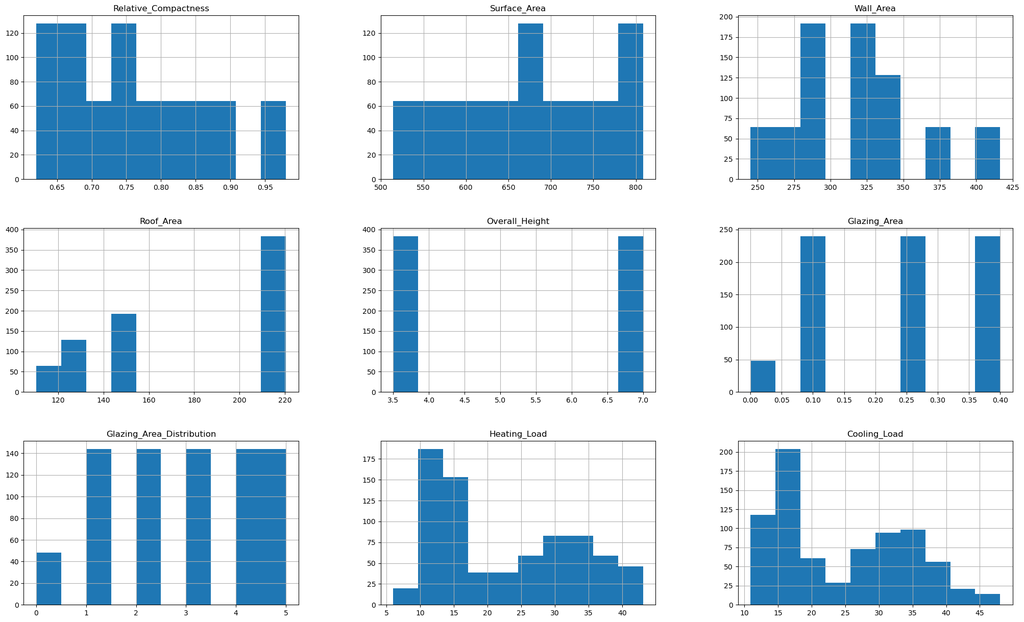

```python
#### TO DO ####
energ.hist(figsize = (25, 15), bins = 10)
```

## Correlation

> Compute and plot the correlation bewteen `Heating_Load` and all the other variables.

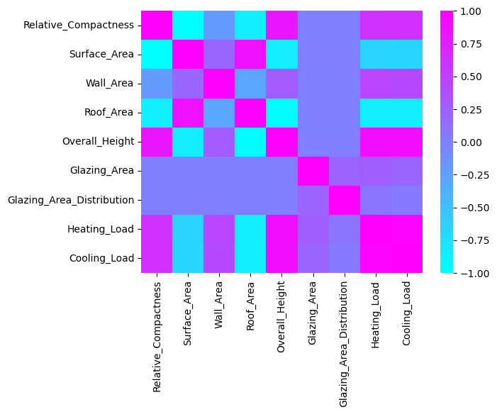

```python
#### TO DO ####
sns.heatmap(energ.corr(), vmin = -1, vmax = 1, cmap = 'cool')
```

```python
#### TO DO ####
```

## Simple Linear regression

We use linear regression to predict `Heating_Load` (or `Cooling Load`) from the other variables. We use the `formula` module from the `statsmodels` library to define these models.

We start with simple linear regression (with a single feature).

```python
import statsmodels.formula.api as smf

# model definition :
my_model = smf.ols('Heating_Load ~ Relative_Compactness',data = energ)

# fit the model on the data (least squares estimation of the coefficients)
res = my_model.fit()
```

```python
res.summary()
```

OLS Regression Results

| Dep. Variable: | Heating_Load | R-squared: | 0.387 |
| --- | --- | --- | --- |
| Model: | OLS | Adj. R-squared: | 0.386 |
| Method: | Least Squares | F-statistic: | 484.0 |
| Date: | Sun, 01 Oct 2023 | Prob (F-statistic): | 1.59e-83 |
| Time: | 11:18:08 | Log-Likelihood: | -2676.5 |
| No. Observations: | 768 | AIC: | 5357. |
| Df Residuals: | 766 | BIC: | 5366. |
| Df Model: | 1 |  |  |
| Covariance Type: | nonrobust |  |  |

|  | coef | std err | t | P>\|t\| | [0.025 | 0.975] |
| --- | --- | --- | --- | --- | --- | --- |
| Intercept | -23.0530 | 2.081 | -11.076 | 0.000 | -27.139 | -18.967 |
| Relative_Compactness | 59.3590 | 2.698 | 22.001 | 0.000 | 54.063 | 64.655 |

| Omnibus: | 53.989 | Durbin-Watson: | 0.305 |
| --- | --- | --- | --- |
| Prob(Omnibus): | 0.000 | Jarque-Bera (JB): | 64.327 |
| Skew: | 0.708 | Prob(JB): | 1.08e-14 |
| Kurtosis: | 3.059 | Cond. No. | 15.0 |

Notes:  
[1] Standard Errors assume that the covariance matrix of the errors is correctly specified.

```python
print('Parameters: ', res.params)
```

```
Parameters:  Intercept              -23.052990
Relative_Compactness    59.359027
dtype: float64
```

```python
print('Predicted values: ', res.fittedvalues) # predictions for `Heating_Load`
```

```
Predicted values:  0      35.118857
1      35.118857
2      35.118857
3      35.118857
4      30.370135
         ...
763    14.936788
764    13.749607
765    13.749607
766    13.749607
767    13.749607
Length: 768, dtype: float64
```

A method called `predict` is also available for prediction with the estimator:

```python
res.predict(energ.iloc[:10,])  # Same as res.fittedvalues
```

```
0    35.118857
1    35.118857
2    35.118857
3    35.118857
4    30.370135
5    30.370135
6    30.370135
7    30.370135
8    27.995774
9    27.995774
dtype: float64
```

Several observations take the same value for `Relative_Compactness`, we then obtain the same prediction of `Heating_Load` for these last.

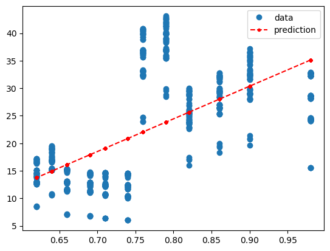

```python
# Plot the regression
fig, ax = plt.subplots()
ax.plot(energ['Relative_Compactness'], energ['Heating_Load'],'o',label="data")
ax.plot(energ['Relative_Compactness'], res.fittedvalues,
        'r--.',label="prediction")
ax.legend(loc='best');
```

We now compute residues:

```python
residues = energ['Heating_Load'] - res.predict(energ['Relative_Compactness'])  # Same as res.resid
print(residues)
```

```
0     -19.568857
1     -19.568857
2     -19.568857
3     -19.568857
4      -9.530135
         ...
763     2.943212
764     2.790393
765     2.690393
766     2.730393
767     2.890393
Length: 768, dtype: float64
```

The sum of squared residuals (or residual sum of squares) is:

```python
print(np.sum(res.resid**2), res.ssr)
```

```
47851.68545625458 47851.68545625458
```

## Several features in the linear regression model

We now define regression model with several features:

```python
import statsmodels.formula.api as smf

model2 =  smf.ols('Heating_Load ~ Relative_Compactness + Wall_Area',data = energ)
res2 = model2.fit()
res2.summary()
```

OLS Regression Results

| Dep. Variable: | Heating_Load | R-squared: | 0.741 |
| --- | --- | --- | --- |
| Model: | OLS | Adj. R-squared: | 0.741 |
| Method: | Least Squares | F-statistic: | 1095. |
| Date: | Sun, 01 Oct 2023 | Prob (F-statistic): | 2.86e-225 |
| Time: | 11:18:08 | Log-Likelihood: | -2345.5 |
| No. Observations: | 768 | AIC: | 4697. |
| Df Residuals: | 765 | BIC: | 4711. |
| Df Model: | 2 |  |  |
| Covariance Type: | nonrobust |  |  |

|  | coef | std err | t | P>\|t\| | [0.025 | 0.975] |
| --- | --- | --- | --- | --- | --- | --- |
| Intercept | -76.8474 | 2.144 | -35.840 | 0.000 | -81.057 | -72.638 |
| Relative_Compactness | 71.1723 | 1.792 | 39.714 | 0.000 | 67.654 | 74.690 |
| Wall_Area | 0.1406 | 0.004 | 32.348 | 0.000 | 0.132 | 0.149 |

| Omnibus: | 42.711 | Durbin-Watson: | 0.299 |
| --- | --- | --- | --- |
| Prob(Omnibus): | 0.000 | Jarque-Bera (JB): | 93.911 |
| Skew: | 0.321 | Prob(JB): | 4.05e-21 |
| Kurtosis: | 4.588 | Cond. No. | 4.57e+03 |

Notes:  
[1] Standard Errors assume that the covariance matrix of the errors is correctly specified.  
[2] The condition number is large, 4.57e+03. This might indicate that there are  
strong multicollinearity or other numerical problems.

The sum of squared residuals (SSR) necessarily decreases as we add more features into the regression:

```python
res2.ssr
```

```
20209.337000890933
```

The coefficients of the models are the following:

```python
res2.params
```

```
Intercept              -76.847444
Relative_Compactness    71.172342
Wall_Area                0.140556
dtype: float64
```

> Check that this vector is equal to the Least Squares Estimator given in the slides of the lecture: $$ \theta = (X'X)^{-1} X' Y $$

```python
#### TO DO ####
# data_clean = energ.dropna()
X = energ[["Relative_Compactness", "Wall_Area"]]
Y = energ["Heating_Load"]
# Add intercept
X = np.column_stack((np.ones(len(X)), X))
parameters = np.linalg.inv(X.T.dot(X)).dot(X.T).dot(Y)
print("Calculated Parameter values:", parameters)
```

```
Calculated Parameter values: [-76.84744398  71.1723422    0.14055608]
```

You can include categorical variables in the model using the `C()` operator:

```python
model3 =  smf.ols('Heating_Load ~ Relative_Compactness + Wall_Area + C(Orientation)',data = energ)
res3 = model3.fit()
res3.summary()
```

OLS Regression Results

| Dep. Variable: | Heating_Load | R-squared: | 0.741 |
| --- | --- | --- | --- |
| Model: | OLS | Adj. R-squared: | 0.740 |
| Method: | Least Squares | F-statistic: | 436.5 |
| Date: | Sun, 01 Oct 2023 | Prob (F-statistic): | 7.56e-221 |
| Time: | 11:18:08 | Log-Likelihood: | -2345.4 |
| No. Observations: | 768 | AIC: | 4703. |
| Df Residuals: | 762 | BIC: | 4731. |
| Df Model: | 5 |  |  |
| Covariance Type: | nonrobust |  |  |

|  | coef | std err | t | P>\|t\| | [0.025 | 0.975] |
| --- | --- | --- | --- | --- | --- | --- |
| Intercept | -76.8418 | 2.172 | -35.373 | 0.000 | -81.106 | -72.577 |
| C(Orientation)[T.3] | 0.0678 | 0.526 | 0.129 | 0.897 | -0.964 | 1.100 |
| C(Orientation)[T.4] | -0.0530 | 0.526 | -0.101 | 0.920 | -1.085 | 0.979 |
| C(Orientation)[T.5] | -0.0375 | 0.526 | -0.071 | 0.943 | -1.069 | 0.994 |
| Relative_Compactness | 71.1723 | 1.796 | 39.638 | 0.000 | 67.648 | 74.697 |
| Wall_Area | 0.1406 | 0.004 | 32.285 | 0.000 | 0.132 | 0.149 |

| Omnibus: | 42.716 | Durbin-Watson: | 0.299 |
| --- | --- | --- | --- |
| Prob(Omnibus): | 0.000 | Jarque-Bera (JB): | 93.926 |
| Skew: | 0.321 | Prob(JB): | 4.02e-21 |
| Kurtosis: | 4.589 | Cond. No. | 4.59e+03 |

Notes:  
[1] Standard Errors assume that the covariance matrix of the errors is correctly specified.  
[2] The condition number is large, 4.59e+03. This might indicate that there are  
strong multicollinearity or other numerical problems.

```python
res3.ssr
```

```
20207.670028625318
```

## Scikit-learn for linear regression

As we can see in the previous procedures, there are many statistical summaries and methods are provided by Statsmodels for the analysis of linear regression, although we have not really exploit these possibilties, by focusing on predictions.

The [scikit-learn library](https://scikit-learn.org/stable/index.html), which is totally dedicated to machine learning methods, obviously provides [linear regression methods](https://scikit-learn.org/stable/modules/generated/sklearn.linear_model.LinearRegression.html) (without statistics). In the following of the labs, we will mainly use [scikit-learn library](https://scikit-learn.org/stable/index.html).

Procedures of scikit-learn generally require numpy arrays (not data frames).

```python
from sklearn.linear_model import LinearRegression

data = energ.values # np array
X_features = data[:,0:6]
y = data[:,9]

reg = LinearRegression().fit(X_features, y)

reg.score(X_features, y)
```

```
0.8446656411336095
```

```python
reg.coef_
```

```
array([-7.08412806e+01, -4.24627991e+11,  4.24627991e+11,  8.49255981e+11,
        4.28405579e+00,  1.21358012e-01])
```

```python
reg.intercept_
```

```
100.93151041666667
```

```python
reg.predict(X_features[1:3,0:6])
```

```
array([29.56284458, 29.6842026 ])
```

```python
y[1:3]
```

```
array([21.33, 21.33])
```

## Exercice

The [Wind Speed dataset](https://www.kaggle.com/datasets/fedesoriano/wind-speed-prediction-dataset?resource=download) contains 6574 instances of daily averaged responses from an array of 5 weather variables sensors embedded in a meteorological station.

The dataset is also avaible [here](https://box.ec-nantes.fr/index.php/s/QHNiDYJZLCY3Pr5).

Propose a similar analysis for the Wind Speed Dataset : exploratory statistics, and then linear regression to predict the Wind Speed Variable.

```python
#### TO DO ####
import numpy as np
import pandas as pd
import seaborn as sns
import matplotlib.pyplot as plt

wind_data = pd.read_csv("wind_dataset.csv")
wind_data.columns = ['DATE','WIND', 'IND', 'RAIN', 'IND_1', 'T_MAX', 'IND_2', 'T_MIN', 'T_MIN_G']
wind_data.head()
```

|  | DATE | WIND | IND | RAIN | IND_1 | T_MAX | IND_2 | T_MIN | T_MIN_G |
| --- | --- | --- | --- | --- | --- | --- | --- | --- | --- |
| 0 | 1961-01-01 | 13.67 | 0 | 0.2 | 0.0 | 9.5 | 0.0 | 3.7 | -1.0 |
| 1 | 1961-01-02 | 11.50 | 0 | 5.1 | 0.0 | 7.2 | 0.0 | 4.2 | 1.1 |
| 2 | 1961-01-03 | 11.25 | 0 | 0.4 | 0.0 | 5.5 | 0.0 | 0.5 | -0.5 |
| 3 | 1961-01-04 | 8.63 | 0 | 0.2 | 0.0 | 5.6 | 0.0 | 0.4 | -3.2 |
| 4 | 1961-01-05 | 11.92 | 0 | 10.4 | 0.0 | 7.2 | 1.0 | -1.5 | -7.5 |

```python
wind_data.info()
```

```
<class 'pandas.core.frame.DataFrame'>
RangeIndex: 6574 entries, 0 to 6573
Data columns (total 9 columns):
 #   Column   Non-Null Count  Dtype
---  ------   --------------  -----
 0   DATE     6574 non-null   object
 1   WIND     6574 non-null   float64
 2   IND      6574 non-null   int64
 3   RAIN     6574 non-null   float64
 4   IND_1    6513 non-null   float64
 5   T_MAX    5953 non-null   float64
 6   IND_2    6513 non-null   float64
 7   T_MIN    5900 non-null   float64
 8   T_MIN_G  6214 non-null   float64
dtypes: float64(7), int64(1), object(1)
memory usage: 462.4+ KB
```

```python
wind_data.isna().sum()
```

```
DATE         0
WIND         0
IND          0
RAIN         0
IND_1       61
T_MAX      621
IND_2       61
T_MIN      674
T_MIN_G    360
dtype: int64
```

```
array([[<Axes: title={'center': 'WIND'}>,
        <Axes: title={'center': 'IND'}>,
        <Axes: title={'center': 'RAIN'}>],
       [<Axes: title={'center': 'IND_1'}>,
        <Axes: title={'center': 'T_MAX'}>,
        <Axes: title={'center': 'IND_2'}>],
       [<Axes: title={'center': 'T_MIN'}>,
        <Axes: title={'center': 'T_MIN_G'}>, <Axes: >]], dtype=object)
```

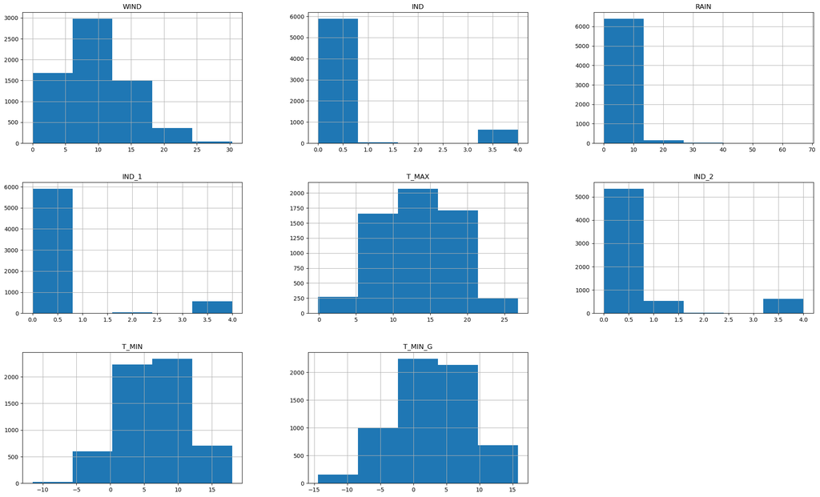

```python
wind_data.hist(figsize = (25, 15), bins = 5)
```

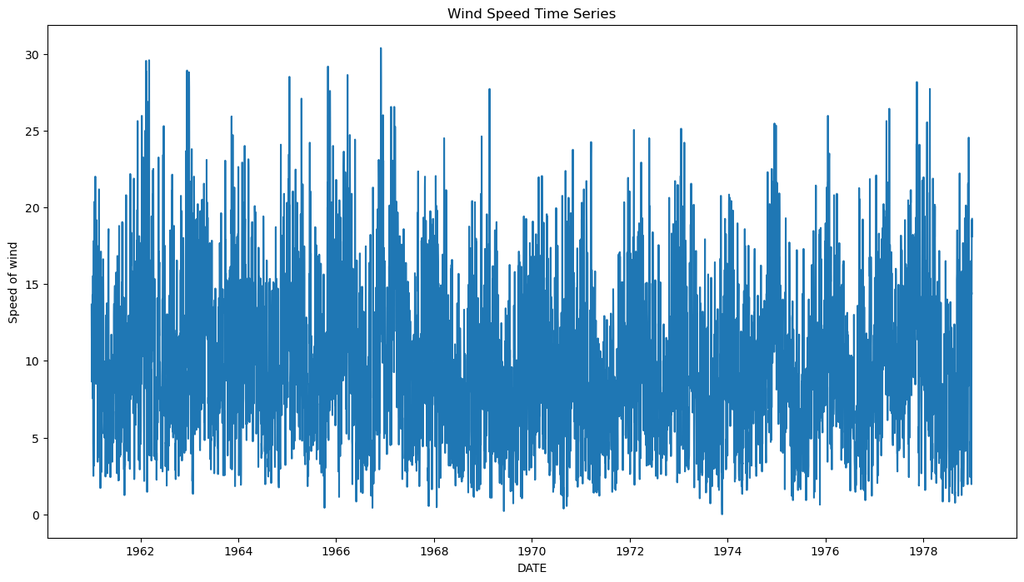

```python
plt.figure(figsize = (15, 8))
wind_data["DATE"] = pd.to_datetime(wind_data["DATE"])
plt.plot(wind_data['DATE'], wind_data['WIND'])
plt.xlabel("DATE")
plt.ylabel("Speed of wind")
plt.title("Wind Speed Time Series")
plt.show()
```

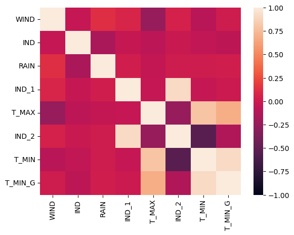

```python
sns.heatmap(wind_data.corr(), vmin = -1, vmax = 1)
```

```python
import statsmodels.formula.api as smf
# model definition :
# IND	RAIN	IND.1	T.MAX	IND.2	T.MIN	T.MIN.G
X = wind_data[["IND", "RAIN", "IND_1", "T_MAX", "IND_2", "T_MIN", "T_MIN_G"]]
Y = wind_data["WIND"]
wind_data["DATE"] = (wind_data["DATE"] - wind_data["DATE"].min()).dt.days
model = smf.ols('WIND ~ IND + RAIN + IND_1 + T_MAX + IND_2 + T_MIN + T_MIN_G', data = wind_data)
# fit the model on the data (least squares estimation of the coefficients)
res = model.fit()

res.summary()
```

OLS Regression Results

| Dep. Variable: | WIND | R-squared: | 0.134 |
| --- | --- | --- | --- |
| Model: | OLS | Adj. R-squared: | 0.133 |
| Method: | Least Squares | F-statistic: | 124.0 |
| Date: | Sun, 01 Oct 2023 | Prob (F-statistic): | 3.78e-170 |
| Time: | 11:18:10 | Log-Likelihood: | -16599. |
| No. Observations: | 5638 | AIC: | 3.321e+04 |
| Df Residuals: | 5630 | BIC: | 3.327e+04 |
| Df Model: | 7 |  |  |
| Covariance Type: | nonrobust |  |  |

|  | coef | std err | t | P>\|t\| | [0.025 | 0.975] |
| --- | --- | --- | --- | --- | --- | --- |
| Intercept | 15.3728 | 0.228 | 67.509 | 0.000 | 14.926 | 15.819 |
| IND | -0.1423 | 0.052 | -2.711 | 0.007 | -0.245 | -0.039 |
| RAIN | 0.1017 | 0.016 | 6.485 | 0.000 | 0.071 | 0.132 |
| IND_1 | 0.2770 | 0.389 | 0.712 | 0.477 | -0.486 | 1.040 |
| T_MAX | -0.4257 | 0.021 | -19.921 | 0.000 | -0.468 | -0.384 |
| IND_2 | -1.7973 | 0.242 | -7.442 | 0.000 | -2.271 | -1.324 |
| T_MIN | -0.1305 | 0.040 | -3.245 | 0.001 | -0.209 | -0.052 |
| T_MIN_G | 0.3039 | 0.027 | 11.445 | 0.000 | 0.252 | 0.356 |

| Omnibus: | 176.879 | Durbin-Watson: | 0.933 |
| --- | --- | --- | --- |
| Prob(Omnibus): | 0.000 | Jarque-Bera (JB): | 193.175 |
| Skew: | 0.444 | Prob(JB): | 1.13e-42 |
| Kurtosis: | 3.181 | Cond. No. | 106. |

Notes:  
[1] Standard Errors assume that the covariance matrix of the errors is correctly specified.

```python
# Coefficients for each independent variables and intercept
print('Parameters: ', res.params)

# The sums of squared residuals(SSR)
res.ssr
```

```
Parameters:  Intercept    15.372761
IND          -0.142306
RAIN          0.101708
IND_1         0.276959
T_MAX        -0.425730
IND_2        -1.797348
T_MIN        -0.130456
T_MIN_G       0.303860
dtype: float64
```

```
119086.64641591415
```

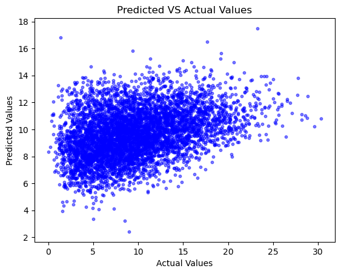

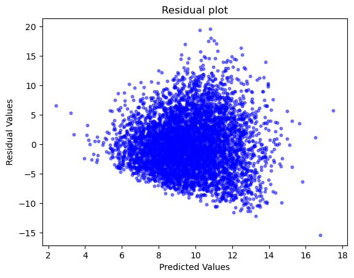

```python
# Plot a scatter plot of predicted versus actual values
data_clean = wind_data.dropna()
Y = data_clean["WIND"]
X = data_clean[["IND", "RAIN", "IND_1", "T_MAX", "IND_2", "T_MIN", "T_MIN_G"]]
plt.scatter(Y, res.fittedvalues, s = 10, alpha = 0.5, c = 'b')
plt.xlabel("Actual Values")
plt.ylabel("Predicted Values")
plt.title("Predicted VS Actual Values")
plt.show()

plt.scatter(res.fittedvalues, res.resid, s = 10, alpha = 0.5, c = 'b')
plt.xlabel("Predicted Values")
plt.ylabel("Residual Values")
plt.title("Residual plot")
plt.show()
```

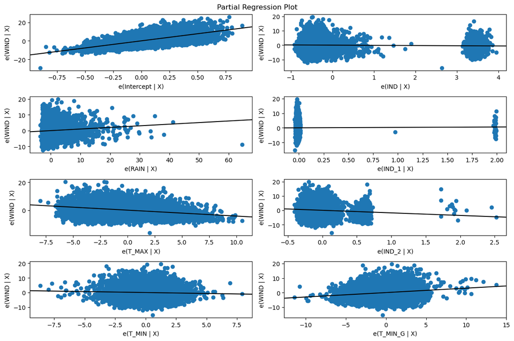

```python
from statsmodels.graphics.regressionplots import plot_partregress_grid
# Draw a partial regression plot
fig = plt.figure(figsize=(12, 8))
plot_partregress_grid(res, fig=fig)
plt.show()
```

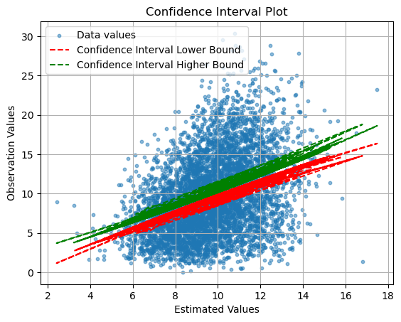

```python
from statsmodels.stats.outliers_influence import summary_table
# Get confidence interval information for coefficients
# Data Includes estimates of regression coefficients, standard errors,
# t-statistics, p-values, and upper and lower bounds for confidence intervals
st, data, ss2 = summary_table(res, alpha=0.05)
ci_low, ci_high = data[:, 4:6].T
predictions = res.get_prediction(X)
mean_values = predictions.predicted_mean
# Plot confidence intervals for coefficients
plt.scatter(mean_values, Y, s = 10, alpha = 0.5, label = "Data values")
plt.plot(mean_values, ci_low, 'r--', label = 'Confidence Interval Lower Bound')
plt.plot(mean_values, ci_high, 'g--', label = 'Confidence Interval Higher Bound')
plt.xlabel('Estimated Values')
plt.ylabel('Observation Values')
plt.title('Confidence Interval Plot')
plt.legend()
plt.grid(True)
plt.show()
```